# notebook

MAF1731 - Microstructure and Trading Systems

B.Eng Financial Engineering

I.F. Ariadna Desirée Galindo Marín

I.F. Francisco Javier Barragán Garcia

Nov 2021 | Repository: [Link](https://github.com/ariadnagalindom/myst_proyecto_1)

Proyecto Final  
Análisis Fundamental

Abstract

The market microstructure is the study of financial markets and how they can operate, primarily focuses on the structure of exchanges and trading venues, the price discovery process, determinants of spreads, and quotes, intraday trading behaviors, and transaction costs. Market microstructure continues to be one of the fastest growing fields of financial research due to the rapid development of algorithmic and electronic trading. In the following project it will be resumed all the techniques learned in the class with a fundamental analysis of an indicator.

# 1. Introduction

La producción de petróleo en el mundo es fundamental ya que representa el motor de la reconología moderna y, pese a las innovaciones en potencia de diversas tecnologías, los combustibles fósiles contemplan al rededor del 95% de todo el transporte a nivel mundial. El indicador seleccionado fue "API Weekly Crude Oil Stock" de Estados Unidos con el principal objetivo de observar el cómo se mueve el mercado, qué afectaciones o alteraciones ha sufrido a partir de la pandemia y cómo se ve beneficiado.

En resumen, la producción del crudo en Estados Unidos depende estréchamente de la necesidad que el mercado manifiesta. Si la producción/extracción de petróleo es mayor que la esperada, eso denota un exceso de demanda del mercado por el producto; Por el contrario, Si es menor, indica una sobreproducción y sobreoferta en el mercado, lo que provoca una baja en las gasolinas a nivel mundial. En Estados Unidos, la producción de las refinerías está topada (85%) por 4 productos principales que son:

- Turbosina
- Keroseno
- Gasolina
- Gasavion

Después de haber sufrido una considerable baja durante el año de la pandemia hasta la reactivación, el mercado se ha repuesto y ha rosado 0.572 millones de barriles producidos en el periodo anterior después de haber sufrido una baja de casi 3 millones de barriles de crudo.

Un sistema de trading tiene la funcionalidad de poder tener una herramienta tácita para observar las operaciones ralizadas con el índice y lo deseado.

En este proyecto, se permite observar, con un método sistémico, cada operación, así como el por ué de las ventas siendo limitadas por un take profit y un stoploss.

# 2. Install/Load Packages and Depedencies

## 2.3 Files Dependencies

The following are the file dependencies that are needed to run this notebook:

- files/precios.csv : Precios históricos
- API Weekly Crude Oil Stock - United States.txt : Datos históricos del índice elegido

## 2.3 Install Packages

```python
%%capture

# Install all the pip packages in the requirements.txt
import sys
!{sys.executable} -m pip install -r requirements.txt
```

# 3. Data Description

```python
import data as d
import functions as f
import visualizations as v
import main as m
import importlib
import pandas as pd
import numpy as np

import matplotlib.pyplot as plt
```

```python
# índice
print(d.indice.head(5))
print(d.indice.tail(5))
```

```
   index            DateTime  Actual  Consensus  Previous
0    110 2018-01-03 21:30:00  -4.992     -6.000    -6.000
1    109 2018-01-09 21:30:00 -11.190     -4.992    -4.992
2    108 2018-01-17 21:30:00  -5.121    -11.190   -11.190
3    107 2018-01-23 21:30:00   4.755     -5.121    -5.121
4    106 2018-01-30 21:30:00   3.229      4.755     4.755
     index            DateTime  Actual  Consensus  Previous
106      4 2020-01-14 21:30:00    1.10     -5.945    -5.945
107      3 2020-01-22 21:30:00    1.60      1.100     1.100
108      2 2020-01-28 21:30:00   -4.27      1.600     1.600
109      1 2020-02-04 21:30:00    4.18     -4.270    -4.270
110      0 2020-02-11 21:30:00    6.00      4.180     4.180
```

**Insertar las divisas elegidas**

```python
# divisa
importlib.reload(d)
divisa = d.historico('EURUSD')
print(divisa.head(5))
print(divisa.tail(5))
```

```
                 time     open     high      low    close  tick_volume  \
0 2018-01-02 00:00:00  1.20087  1.20095  1.20007  1.20090          705
1 2018-01-02 00:15:00  1.20090  1.20094  1.20034  1.20058         1083
2 2018-01-02 00:30:00  1.20059  1.20160  1.20058  1.20135          969
3 2018-01-02 00:45:00  1.20135  1.20141  1.20125  1.20130         1234
4 2018-01-02 01:00:00  1.20130  1.20139  1.20019  1.20137         4787

   spread  real_volume
0      16    155200000
1      19    216600000
2      18    193800000
3      20    246800000
4      18    957400000
                     time     open     high      low    close  tick_volume  \
53583 2020-02-28 22:45:00  1.10445  1.10446  1.10328  1.10371        12727
53584 2020-02-28 23:00:00  1.10372  1.10424  1.10232  1.10279         8632
53585 2020-02-28 23:15:00  1.10279  1.10318  1.10261  1.10305         3709
53586 2020-02-28 23:30:00  1.10305  1.10394  1.10302  1.10309         4400
53587 2020-02-28 23:45:00  1.10309  1.10320  1.10233  1.10262         4538

       spread  real_volume
53583      15   1909050000
53584      15   1294800000
53585      15    556350000
53586      15    660000000
53587      13    680700000
```

Una vez que tenemos los datos necesarios vamos a proceder a clasificarlos escenarios usando la siguiente tabla.

```python
m.escenarios
```

|  | Escenario | Regla |
| --- | --- | --- |
| 0 | A | Actual>=Consensus>=Previous |
| 1 | B | Actual>=Consensus<Previous |
| 2 | C | Actual<Consensus>=Previous |
| 3 | D | Actual<Consensus<Previous |

```python
df_index = f.clas_esc(d.indice)
df_index.head(7)
```

|  | DateTime | Actual | Consensus | Previous | Escenario | Operacion |
| --- | --- | --- | --- | --- | --- | --- |
| 0 | 2018-01-03 21:30:00 | -4.992 | -6.000 | -6.000 | A | Sell |
| 1 | 2018-01-09 21:30:00 | -11.190 | -4.992 | -4.992 | C | Buy |
| 2 | 2018-01-17 21:30:00 | -5.121 | -11.190 | -11.190 | A | Sell |
| 3 | 2018-01-23 21:30:00 | 4.755 | -5.121 | -5.121 | A | Sell |
| 4 | 2018-01-30 21:30:00 | 3.229 | 4.755 | 4.755 | C | Buy |
| 5 | 2018-02-06 21:30:00 | -1.050 | 3.229 | 3.229 | C | Buy |
| 6 | 2018-02-13 21:30:00 | 3.940 | -1.050 | -1.050 | A | Sell |

**Validaciones**

```python
v1 = d.indice.Actual == -7.900
v1 = d.indice[v1]
v1
```

|  | DateTime | Actual | Consensus | Previous |
| --- | --- | --- | --- | --- |
| 7 | 2019-12-24 21:30:00 | -7.9 | 4.7 | 4.7 |

[figure not shown]

Para este día el indicador bajo mucho más de lo que se esperaba.

```python
# parámetros de la operación
#sentido
fecha = '2019-12-24'
tipo = 'compra'
inicial, final, p_max, p_min = 1.1089, 1.1087, 1.1095, 1.1069
#volumen
#TP
#SL
```

```python
v2 = d.indice.Actual == 6.000
v2 = d.indice[v2]
v2
```

|  | DateTime | Actual | Consensus | Previous |
| --- | --- | --- | --- | --- |
| 0 | 2020-02-11 21:30:00 | 6.0 | 4.18 | 4.18 |

[figure not shown]

Para este día el indicador superó las expectativas

```python
v3 = d.indice.Actual == -11.100
v3 = d.indice[v3]
v3
```

|  | DateTime | Actual | Consensus | Previous |
| --- | --- | --- | --- | --- |
| 24 | 2019-08-27 20:30:00 | -11.1 | -3.5 | -3.5 |

[figure not shown]

Para este día el indicador bajo mucho más de lo que se esperaba.

```python
v4 = d.indice.Actual == -5.945
v4 = d.indice[v4]
v4
```

|  | DateTime | Actual | Consensus | Previous |
| --- | --- | --- | --- | --- |
| 5 | 2020-01-07 21:30:00 | -5.945 | -7.8 | -7.8 |

[figure not shown]

Este día el indicador bajo menos de lo esperado.

```python
v5 = d.indice.Actual == 4.850
v5 = d.indice[v5]
v5
```

|  | DateTime | Actual | Consensus | Previous |
| --- | --- | --- | --- | --- |
| 35 | 2019-06-11 20:30:00 | 4.85 | 3.545 | 3.545 |

[figure not shown]

Este día el indicador subió más de lo esperado.

### Aspectos estadísticos del indicador

Serie de tiempo del indicador Actual

```python
v.linea(d.indice)
```

[output not shown]

1. **Componente de Autocorrelación y Autocorrelación Parcial**

```
(<Figure size 432x288 with 1 Axes>, <Figure size 432x288 with 1 Axes>)
```

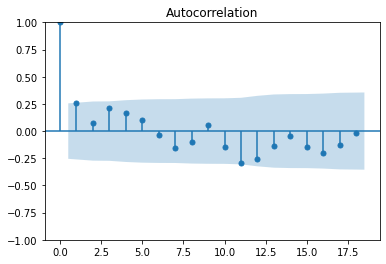

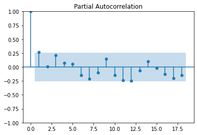

```python
v.autocorr(d.indice)
```

[figure not shown]

```python
v.hetero(d.indice)
```

1. **Prueba de Normalidad**

```python
v.normalidad(d.indice)
```

```
Kursotis: -0.7765876349068872
Skewness: -0.20907918782016474
Shapiro-Wilk:  ShapiroResult(statistic=0.9768641591072083, pvalue=0.3211085796356201)
D Agostino: NormaltestResult(statistic=3.044428424304445, pvalue=0.21822814818205835)
```

Después de realizar varias pruebas de normalidad y analizar los p-values, podemos decir que ninguno de los test muestra evidencias para rechazar la hipótesis de que los datos siguen una distribución normal.

4-5 **Estacionalidad y Estacionariedad**

```
Hay evidencia de estacionariedad
(None, 6.303832892951583e-07)
```

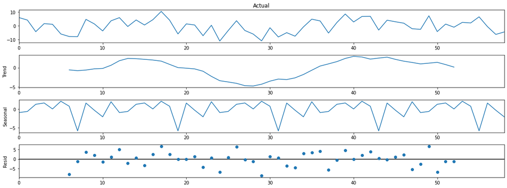

```
(None, None)
```

```python
v.estacion(d.indice)
```

1. **Detección de Atípicos**

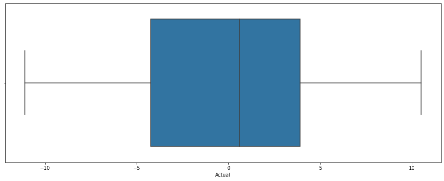

```python
v.atipicos(d.indice)
```

Podemos apreciar que no hay datos atípicos.

**Aspectos Computacionales**

Hacemos la clasificación por escenarios utilizando la siguiente regla:

```python
m.escenarios
```

|  | Escenario | Regla |
| --- | --- | --- |
| 0 | A | Actual>=Consensus>=Previous |
| 1 | B | Actual>=Consensus<Previous |
| 2 | C | Actual<Consensus>=Previous |
| 3 | D | Actual<Consensus<Previous |

```python
fechas, escenario, direccion, pip_bajista, pip_alcista, volatilidad =f.get_metricas(df_index,d.divisa)
```

# Etapa 4: Optimización y Backtest

```python
capital = 100000
perdida = 1000
```

```python
df_escenarios= f.escenarios( fechas, escenario, direccion, pip_bajista, pip_alcista, volatilidad)
```

```python
df_test,df_train = f.entrenamiento(df_escenarios)
df_train.head()
```

|  | TimeStamp | escenario | direccion | pip_alcista | pip_bajista | volatilidad |
| --- | --- | --- | --- | --- | --- | --- |
| 0 | 2018-01-03 21:30:00 | A | -1 | 1.0 | 1.0 | 6.0 |
| 1 | 2018-01-09 21:30:00 | C | 1 | 0.0 | 1.0 | 3.0 |
| 2 | 2018-01-17 21:30:00 | A | -1 | 5.0 | 1.0 | 7.0 |
| 3 | 2018-01-23 21:30:00 | A | -1 | 0.0 | 1.0 | 9.0 |
| 4 | 2018-01-30 21:30:00 | C | 1 | 1.0 | 1.0 | 12.0 |

```python
df_test, df_train = f.entrenamiento(df_escenarios)
df_train.head()
```

|  | TimeStamp | escenario | direccion | pip_alcista | pip_bajista | volatilidad |
| --- | --- | --- | --- | --- | --- | --- |
| 0 | 2018-01-03 21:30:00 | A | -1 | 1.0 | 1.0 | 6.0 |
| 1 | 2018-01-09 21:30:00 | C | 1 | 0.0 | 1.0 | 3.0 |
| 2 | 2018-01-17 21:30:00 | A | -1 | 5.0 | 1.0 | 7.0 |
| 3 | 2018-01-23 21:30:00 | A | -1 | 0.0 | 1.0 | 9.0 |
| 4 | 2018-01-30 21:30:00 | C | 1 | 1.0 | 1.0 | 12.0 |

```python
df_decisiones, tiempo = f.decisiones(df_escenarios)
df_decisiones.head()
```

|  | escenario | operacion | SL | TP | volumen |
| --- | --- | --- | --- | --- | --- |
| 0 | A | Sell | 20 | 30 | 100 |
| 1 | C | Buy | 20 | 30 | 100 |
| 2 | A | Sell | 20 | 30 | 100 |
| 3 | C | Sell | 20 | 30 | 100 |
| 4 | A | Buy | 20 | 30 | 100 |

```python
divisa
```

|  | time | open | high | low | close | tick_volume | spread | real_volume |
| --- | --- | --- | --- | --- | --- | --- | --- | --- |
| 0 | 2018-01-02 00:00:00 | 1.20087 | 1.20095 | 1.20007 | 1.20090 | 705 | 16 | 155200000 |
| 1 | 2018-01-02 00:15:00 | 1.20090 | 1.20094 | 1.20034 | 1.20058 | 1083 | 19 | 216600000 |
| 2 | 2018-01-02 00:30:00 | 1.20059 | 1.20160 | 1.20058 | 1.20135 | 969 | 18 | 193800000 |
| 3 | 2018-01-02 00:45:00 | 1.20135 | 1.20141 | 1.20125 | 1.20130 | 1234 | 20 | 246800000 |
| 4 | 2018-01-02 01:00:00 | 1.20130 | 1.20139 | 1.20019 | 1.20137 | 4787 | 18 | 957400000 |
| ... | ... | ... | ... | ... | ... | ... | ... | ... |
| 53583 | 2020-02-28 22:45:00 | 1.10445 | 1.10446 | 1.10328 | 1.10371 | 12727 | 15 | 1909050000 |
| 53584 | 2020-02-28 23:00:00 | 1.10372 | 1.10424 | 1.10232 | 1.10279 | 8632 | 15 | 1294800000 |
| 53585 | 2020-02-28 23:15:00 | 1.10279 | 1.10318 | 1.10261 | 1.10305 | 3709 | 15 | 556350000 |
| 53586 | 2020-02-28 23:30:00 | 1.10305 | 1.10394 | 1.10302 | 1.10309 | 4400 | 15 | 660000000 |
| 53587 | 2020-02-28 23:45:00 | 1.10309 | 1.10320 | 1.10233 | 1.10262 | 4538 | 13 | 680700000 |

53588 rows × 8 columns

```python
df_backtest = pd.DataFrame()
df_backtest['DateTime'] = tiempo
a = list(df_decisiones.escenario)
df_backtest['escenario'] = a
a = list(df_decisiones.operacion)
df_backtest['operacion'] = a
df_backtest['volumen'] = 100
df_backtest = df_backtest.reset_index()
df_backtest = df_backtest.drop(['index'], axis=1)

df_backtest.head()
```

|  | DateTime | escenario | operacion | volumen |
| --- | --- | --- | --- | --- |
| 0 | 2019-02-05 21:30:00 | A | Sell | 100 |
| 1 | 2019-02-12 21:30:00 | C | Buy | 100 |
| 2 | 2019-02-20 21:30:00 | A | Sell | 100 |
| 3 | 2019-02-26 21:30:00 | C | Sell | 100 |
| 4 | 2019-03-05 21:30:00 | A | Buy | 100 |

```python
len(pips)
```

```
50
```

```python
importlib.reload(f)
```

```
<module 'functions' from 'c:\\Users\\ariad\\OneDrive\\Documentos\\GitHub\\myst_proyecto_1\\functions.py'>
```

```python
df_backtest = f.backtest(df_decisiones, divisa, tiempo)
```

```python
df_backtest
```

|  | DateTime | escenario | operacion | volumen | resultado | pips | capital | capital_acm |
| --- | --- | --- | --- | --- | --- | --- | --- | --- |
| 0 | 2019-02-05 21:30:00 | A | Sell | 1000 | ganada | 0.1 | 0.008327 | 100000.008327 |
| 1 | 2019-02-12 21:30:00 | C | Buy | 1000 | perdida | 0.0 | -0.008327 | 99999.991673 |
| 2 | 2019-02-20 21:30:00 | A | Sell | 1000 | ganada | 0.1 | 0.008327 | 100000.008327 |
| 3 | 2019-02-26 21:30:00 | C | Sell | 1000 | ganada | 0.2 | 0.008327 | 100000.008327 |
| 4 | 2019-03-05 21:30:00 | A | Buy | 1000 | perdida | 0.1 | -0.008327 | 99999.991673 |
| 5 | 2019-03-12 20:30:00 | C | Buy | 1000 | perdida | 0.0 | -0.008327 | 99999.991673 |
| 6 | 2019-03-19 20:30:00 | A | Sell | 1000 | ganada | 0.1 | 0.008327 | 100000.008327 |
| 7 | 2019-03-26 20:30:00 | A | Buy | 1000 | perdida | 0.0 | -0.008327 | 99999.991673 |
| 8 | 2019-04-02 20:30:00 | A | Sell | 1000 | ganada | 0.1 | 0.008327 | 100000.008327 |
| 9 | 2019-04-09 20:30:00 | A | Sell | 1000 | ganada | 0.2 | 0.008327 | 100000.008327 |
| 10 | 2019-04-16 20:30:00 | C | Buy | 1000 | perdida | 0.1 | -0.008327 | 99999.991673 |
| 11 | 2019-04-23 20:30:00 | A | Buy | 1000 | perdida | 0.0 | -0.008327 | 99999.991673 |
| 12 | 2019-04-30 20:30:00 | C | Sell | 1000 | ganada | 0.1 | 0.008327 | 100000.008327 |
| 13 | 2019-05-07 20:30:00 | C | Buy | 1000 | perdida | 0.0 | -0.008327 | 99999.991673 |
| 14 | 2019-05-14 20:30:00 | A | Sell | 1000 | ganada | 0.1 | 0.008327 | 100000.008327 |
| 15 | 2019-05-21 21:30:00 | C | Buy | 1000 | perdida | 0.0 | -0.008327 | 99999.991673 |
| 16 | 2019-05-29 20:30:00 | C | Sell | 1000 | ganada | 0.1 | 0.008327 | 100000.008327 |
| 17 | 2019-06-04 20:30:00 | A | Sell | 1000 | ganada | 0.2 | 0.008327 | 100000.008327 |
| 18 | 2019-06-11 20:30:00 | A | Buy | 1000 | perdida | 0.1 | -0.008327 | 99999.991673 |
| 19 | 2019-06-18 20:30:00 | C | Sell | 1000 | ganada | 0.2 | 0.008327 | 100000.008327 |
| 20 | 2019-06-25 20:30:00 | C | Buy | 1000 | perdida | 0.1 | -0.008327 | 99999.991673 |
| 21 | 2019-07-02 20:30:00 | A | Sell | 1000 | ganada | 0.2 | 0.008327 | 100000.008327 |
| 22 | 2019-07-09 20:30:00 | C | Buy | 1000 | perdida | 0.1 | -0.008327 | 99999.991673 |
| 23 | 2019-07-16 20:30:00 | A | Sell | 1000 | ganada | 0.2 | 0.008327 | 100000.008327 |
| 24 | 2019-07-23 20:30:00 | C | Buy | 1000 | perdida | 0.1 | -0.008327 | 99999.991673 |
| 25 | 2019-07-30 20:30:00 | A | Buy | 1000 | perdida | 0.0 | -0.008327 | 99999.991673 |
| 26 | 2019-08-06 20:30:00 | A | Sell | 1000 | ganada | 0.1 | 0.008327 | 100000.008327 |
| 27 | 2019-08-13 20:30:00 | A | Buy | 1000 | perdida | 0.0 | -0.008327 | 99999.991673 |
| 28 | 2019-08-20 21:30:00 | C | Sell | 1000 | ganada | 0.1 | 0.008327 | 100000.008327 |
| 29 | 2019-08-27 20:30:00 | C | Buy | 1000 | perdida | 0.0 | -0.008327 | 99999.991673 |
| 30 | 2019-09-04 20:30:00 | A | Sell | 1000 | ganada | 0.1 | 0.008327 | 100000.008327 |
| 31 | 2019-09-10 20:30:00 | C | Buy | 1000 | perdida | 0.0 | -0.008327 | 99999.991673 |
| 32 | 2019-09-17 21:30:00 | A | Sell | 1000 | ganada | 0.1 | 0.008327 | 100000.008327 |
| 33 | 2019-09-24 20:30:00 | A | Buy | 1000 | perdida | 0.0 | -0.008327 | 99999.991673 |
| 34 | 2019-10-01 20:30:00 | C | Sell | 1000 | ganada | 0.1 | 0.008327 | 100000.008327 |
| 35 | 2019-10-08 20:30:00 | A | Buy | 1000 | perdida | 0.0 | -0.008327 | 99999.991673 |
| 36 | 2019-10-16 20:30:00 | A | Buy | 1000 | perdida | -0.1 | -0.008327 | 99999.991673 |
| 37 | 2019-10-22 20:30:00 | C | Sell | 1000 | ganada | 0.0 | 0.008327 | 100000.008327 |
| 38 | 2019-10-29 20:30:00 | C | Sell | 1000 | ganada | 0.1 | 0.008327 | 100000.008327 |
| 39 | 2019-11-05 21:30:00 | A | Buy | 1000 | perdida | 0.0 | -0.008327 | 99999.991673 |
| 40 | 2019-11-13 21:30:00 | C | Sell | 1000 | ganada | 0.1 | 0.008327 | 100000.008327 |
| 41 | 2019-11-19 21:30:00 | A | Buy | 1000 | perdida | 0.0 | -0.008327 | 99999.991673 |
| 42 | 2019-11-26 21:30:00 | C | Sell | 1000 | ganada | 0.1 | 0.008327 | 100000.008327 |
| 43 | 2019-12-03 21:30:00 | C | Buy | 1000 | perdida | 0.0 | -0.008327 | 99999.991673 |
| 44 | 2019-12-10 21:30:00 | A | Sell | 1000 | ganada | 0.1 | 0.008327 | 100000.008327 |
| 45 | 2019-12-17 21:30:00 | A | Sell | 1000 | ganada | 0.2 | 0.008327 | 100000.008327 |
| 46 | 2020-01-07 21:30:00 | A | Buy | 1000 | perdida | 0.1 | -0.008327 | 99999.991673 |
| 47 | 2020-01-14 21:30:00 | A | Sell | 1000 | ganada | 0.2 | 0.008327 | 100000.008327 |
| 48 | 2020-01-22 21:30:00 | A | Sell | 1000 | ganada | 0.3 | 0.008327 | 100000.008327 |
| 49 | 2020-01-28 21:30:00 | C | Buy | 1000 | perdida | 0.2 | -0.008327 | 99999.991673 |

# 5. Results

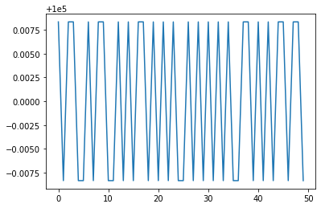

```python
plt.plot(df_backtest.capital_acm)
```

# 6. Conclusions

Este sistema y el uso que se le puede dar es tan simple que lo pueden emplear personas sin conocimiento alguno de las finanzas y de lo que comprende e incluye un macroproceso de esta magnitud. Mucha dificultad pero con estrategia, se puede disuadir y analizar parte por parte, en resumidas cuentas, desmenusar el proceso de principio a fin.

# 7. References

- https://www.delftstack.com/es/howto/python-pandas/how-to-load-data-from-txt-with-pandas/
- https://adpemploymentreport.com/
- https://stackoverflow.com/questions/26266362/how-to-count-the-nan-values-in-a-column-in-pandas-dataframe
- https://www.geeksforgeeks.org/autocorrelation-plot-using-matplotlib/
- https://machinelearningmastery.com/gentle-introduction-autocorrelation-partial-autocorrelation/
- https://www.cienciadedatos.net/documentos/pystats06-analisis-normalidad-python.html

y tan tan, este semestre se ha acabado :)